# Final Report

Rosie Zou, Alvin Chow, and Abhijeet Hara

## Problem Introduction:

Our project dives into the world of financial data and aims to predict retained earnings of different companies using key statistics found on the companies’ income and cash flow statements as well as market-influenced metrics. We were motivated by the potential applications of a highly-precise model that predicts a company’s retained earnings. By definition, retained earnings is a value recorded under shareholders’ equity on the balance sheet, and refers to the percentage of a company’s net earnings not paid out to investors as dividends, but retained by the company to be reinvested in its core business, or to pay debt. We are interested in predicting this value since it provides significant insights into a company’s financial well-being, and can be a very useful reference for business analysts and portfolio managers to adjust their clients’ investments. Throughout the next few sections, we will describe in details the process behind preliminary data processing, variable selection, and parameter tuning. Our objective throughout the project was to build a model that minimizes the APSE.

## Data and Preprocessing:

The data set used in this project is collected from [Quandl.com](https://quandl.com) and published by Sharadar, an independent research and analytics company that specializes in extraction, standardization and organization of financial data from company filings. The **Core US Fundamentals Data** consists of over 100 essential and fundamental financial metrics for over 10000 companies, gathered over 16 years. These metrics are gathered from publically released **income statements**, **cash flow statements**, **balance sheets**, and **closing prices**. The value of interest as explained earlier is retained earnings, which is denoted as **retearn** in the data set.

One of the biggest challenges in this data set is the amount of missing data. Since 5000 of the companies have been delisted already, a lot of those companies have several columns with missing values. In order to retain the most amount of information possible, we need to do some pre-processing.

Below is a quick preview of what the data is like:

```r
options(scipen=999)
all_data=read.csv('SHARADAR-SF1-2.csv')
dim(all_data)
head(all_data[,c(3:13)],10)
```

[output not shown]

The csv file has about 10,000 observations, and about 111 columns, which means it has a maximum of 110 predictors, and 1 response column.

It can be seen that the data has quite a few blanks in there. To see how many of the rows are fully usable (including outliers), we can examine how much data is left, after removing all the NAs.

```r
all_data=read.csv('SHARADAR-SF1-2.csv')
all_data=na.omit(all_data)
dim(all_data)
```

[output not shown]

About half of the data gets removed, but the observations that currently exist now are unscaled, and may contain outliers

To figure out if it is worth scaling, we can look at a few histograms to see the overall spread

```r
hist(all_data[,'retearn'],ylim=c(0,2000),xlab='Retained Earnings',ylab='Frequency',main='Histogram of Retained Earnings',
     col='white')
summary(all_data[,'retearn'])
```

[output not shown]

If we were to evaluate the goodness of fit of a model using APSE, the numbers that we would get will be extremely large to look at (around 26 digit), in order to address this, the data needs to be scaled down. There are many ways to do this such as:

#### Standard Scaler

The Standard Scaler is defined by the formula
$$\frac{x_{i}-mean(x)}{stddev(x)}$$

#### Min Max Scaler

The Min Max Scaler is defined by the formula
$$\frac{x_{i}-min(x)}{max(x)-min(x)}$$

#### Robust Scaler

It follow a similar approach to the min max scaler, except this scaler relies on the Interquartile Range. The advantage this technique have over the other methods is that this one is not sensitive to outliers, since it relies on the data’s percentiles in order to do the transformations, which the histogram clearly showed the data does have some extremely large outliers. This technique will be able to scale the data down quite well, while at the same time preserving the natural underlying structure of the data

### Scaling and Splitting

```python
import pandas as pd
from sklearn.preprocessing import RobustScaler,robust_scale
import numpy as np
from sklearn.model_selection import train_test_split
all_data=pd.read_csv('SHARADAR-SF1-2.csv')
no_blanks=all_data.dropna()
#run: len(no_blanks['retearn']), will get = 5351, which means 5351 have no blanks
blanks=all_data.loc[pd.isnull(all_data).any(1),:]
#run: len(blanks['retearn']), will get = 4649, which means 4649 have a blank in their row

no_blanks=no_blanks.drop(no_blanks.columns[[0,1,2,3,4,5]],axis=1)

scaled=pd.DataFrame(robust_scale(no_blanks))
column_names=list(no_blanks)
scaled.columns=column_names
new_scaled=scaled.set_index('retearn').reset_index()

all_data=new_scaled

Y=all_data['retearn']
all_data=all_data.drop('retearn',1)

X_train, X_test, Y_train, Y_test = train_test_split(all_data,Y,test_size=0.1, random_state=123456)

pd.DataFrame.to_csv(X_train,'X_train.csv',index=False)
pd.DataFrame.to_csv(X_test,'X_test.csv',index=False)
Y_train=np.transpose((Y_train.values)[np.newaxis])
Y_test=np.transpose((Y_test.values)[np.newaxis])
np.savetxt('Y_train.csv',Y_train)
np.savetxt('Y_test.csv',Y_test)
```

```python
import pandas as pd
from sklearn.preprocessing import RobustScaler,robust_scale
import numpy as np
from sklearn.model_selection import train_test_split
all_data=pd.read_csv('SHARADAR-SF1-2.csv')
no_blanks=all_data.dropna()
#run: len(no_blanks['retearn']), will get = 5351, which means 5351 have no blanks
blanks=all_data.loc[pd.isnull(all_data).any(1),:]
#run: len(blanks['retearn']), will get = 4649, which means 4649 have a blank in their row

no_blanks=no_blanks.drop(no_blanks.columns[[0,1,2,3,4,5]],axis=1)

scaled=pd.DataFrame(robust_scale(no_blanks))
column_names=list(no_blanks)
scaled.columns=column_names
new_scaled=scaled.set_index('retearn').reset_index()

all_data=new_scaled

Y=all_data['retearn']
all_data=all_data.drop('retearn',1)
#DUPES 2#

for i in (range(2,6)):
    X_traini, X_testi, Y_traini, Y_testi = train_test_split(all_data, Y, test_size=0.1, random_state=i)
    text_new_train = 'X_train' + str(i) + ".csv"
    text_new_test = 'X_test' + str(i) + ".csv"
    pd.DataFrame.to_csv(X_traini, text_new_train, index=False)
    pd.DataFrame.to_csv(X_testi, text_new_test, index=False)
    Y_traini = np.transpose((Y_traini.values)[np.newaxis])
    Y_testi = np.transpose((Y_testi.values)[np.newaxis])
    text_new_train = 'Y_train' + str(i) + ".csv"
    text_new_test = 'Y_test' + str(i) + ".csv"
    np.savetxt(text_new_train, Y_traini)
    np.savetxt(text_new_test, Y_testi)
```

The above code segment creates a for loop which creates 4 more randomely generated copies of the above files.

A quick preview of the train and test is below:

### X_train/X_test

```r
all_data=read.csv('X_train.csv')
head(all_data[,c(1:10)],10)
```

```
##           accoci       assets   assetsavg     assetsc    assetsnc
## 1   5.555556e-04 -0.167008018 -0.16578359 -0.18835855 -0.13316412
## 2  -5.666667e-03 -0.175240418 -0.17182569 -0.21753588 -0.13134623
## 3   2.491111e-01 -0.187598955 -0.18333210 -0.24767911 -0.13590715
## 4   5.555556e-04 -0.164381563 -0.15764459 -0.19569177 -0.12486147
## 5   5.555556e-04 -0.007750646 -0.04222501  0.17059290 -0.05865145
## 6   5.555556e-04 -0.190833518 -0.18745944 -0.25618120 -0.13677379
## 7   5.555556e-04  0.290797831  0.32990545 -0.03774164  0.55139119
## 8   5.555556e-04  0.510196773  0.58021154  0.06729673  0.86192032
## 9   5.555556e-04 -0.184171140 -0.18117892 -0.25336451 -0.12714504
## 10 -1.091333e+03 37.435051703 37.77002140 34.78918624 44.02680251
##    assetturnover       bvps        capex    cashneq  cashnequsd
## 1     -0.4044032  0.2887832   0.13271749 -0.0444367 -0.04441221
## 2      1.2549247 -0.3693222   0.13232521 -0.1970320 -0.20507190
## 3      0.4553882 -0.5267539   0.13337551 -0.2404181 -0.25075080
## 4      4.8238702 -0.4646056   0.14033534 -0.2448944 -0.25546366
## 5      7.6662804 -0.1511692   0.00635242 -0.1455519 -0.15087112
## 6      0.8377752 -0.5929449   0.14384056 -0.2446156 -0.25517020
## 7      0.5909618  1.1823226  -1.15443214 -0.1954266 -0.20338161
## 8      1.1726535 -0.1078082  -0.74535906  0.2113865  0.22493075
## 9     -0.6604867 -0.3108205   0.14433439 -0.2397363 -0.25003297
## 10    -0.1425261  1.3399921 -49.42158810 36.5848198 38.52062579
```

### Y_train/Y_test

```r
all_data=read.csv('Y_train.csv',header=F)
head(all_data[,1],10)
```

```
##  [1] -0.563392524 -0.355265577 -0.137120634  0.009097545  0.011038740
##  [6] -0.052410058  1.888638656  4.485896243 -0.140858503 67.613340985
```

And the new scale of the dataset is:

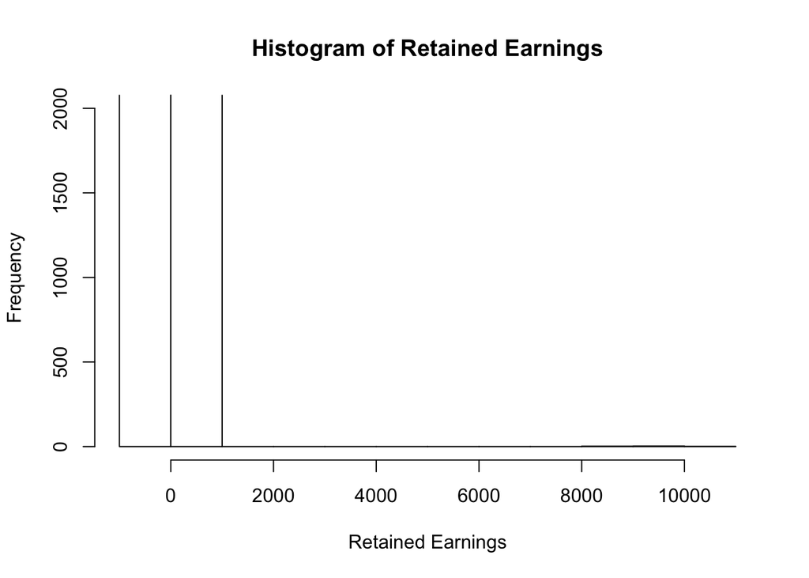

```r
hist(all_data[,1],ylim=c(0,2000),xlab='Retained Earnings',ylab='Frequency',main='Histogram of Retained Earnings',
     col='white')
```

For a better preview, we can ignore the extreme values

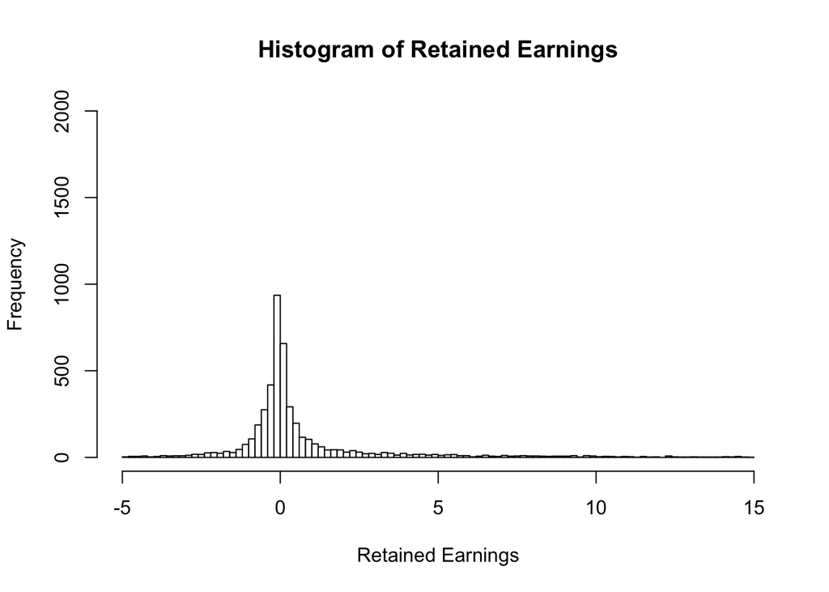

```r
all_data=subset(all_data, V1<=15 & V1>=-5)
hist(all_data[,1],breaks=100,ylim=c(0,2000),xlab='Retained Earnings',ylab='Frequency',main='Histogram of Retained Earnings',
     col='white')
```

```r
all_data=read.csv('Y_train.csv',header=F)
summary(all_data[,1])
```

```
##      Min.   1st Qu.    Median      Mean   3rd Qu.      Max.
##   -38.945    -0.305     0.002    13.652     0.724 10377.126
```

Additionally, an important value to consider in this data set is **fxusd**, where a non-zero value indicates that foreign exchange rate was applicable in gathering the data. We believed that a company’s country of origin would be a reasonable indicator value to have in determining its retained earnings, therefore we create a new categorical variable called **foreign** in the code segment below to indicate whether the company report is domestic or foreign. This variable would later be used in tree-based methods such as random forest and boosting. We also load any necessary libraries and pre-processed data in the code below.

```r
library(randomForest)
library(mgcv)
library(gbm)
options(warn=-1)
# Reading data from csv cleaned files
x_test = read.csv ("X_test.csv",header = T)
y_test = read.csv ("Y_test.csv",header = F)
x_train = read.csv("X_train.csv",header = T)
y_train = read.csv ("Y_train.csv",header = F)

x_train$foreign <- factor(ifelse(x_train$fxusd!=0.000, "Foreign", "Domestic"))
x_test$foreign <- factor(ifelse(x_test$fxusd!=0.000, "Foreign", "Domestic"))
```

Next we need to empirically visualize the response variable, we do so by plotting the empirical CDF, the empirical PDF (histogram), the scatter plot, as well as querying the range of teh response variable:

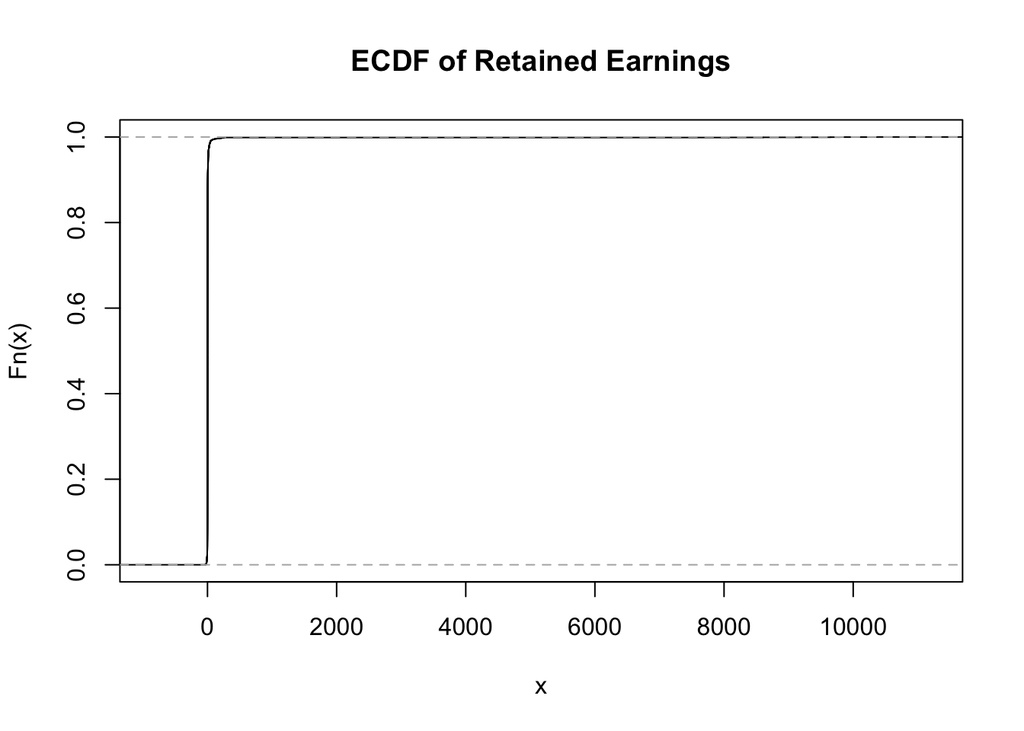

```r
y_train_ecdf <- ecdf(unlist(y_train))
plot(y_train_ecdf, main = "ECDF of Retained Earnings")
```

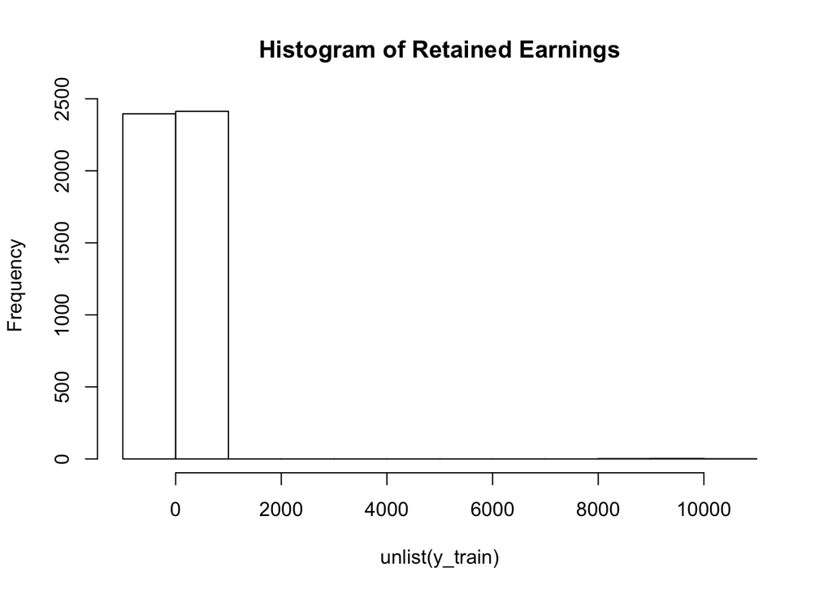

```r
hist(unlist(y_train), main = "Histogram of Retained Earnings")
```

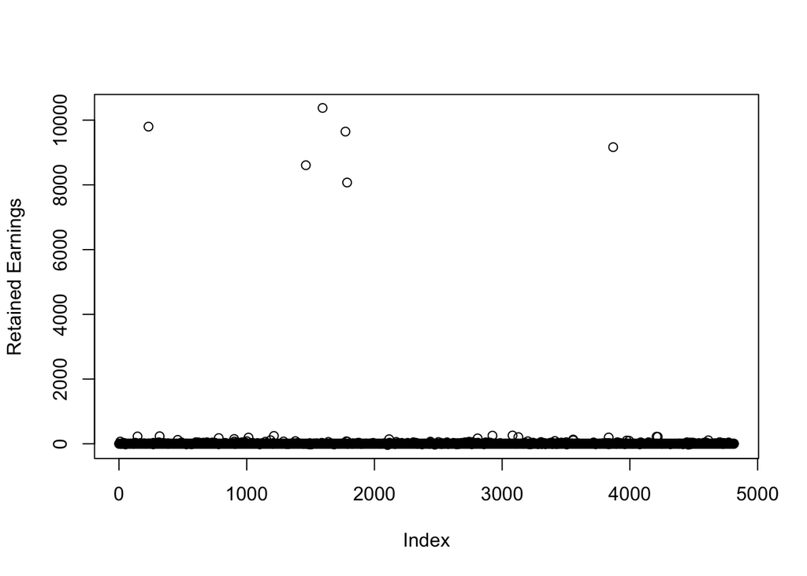

```r
plot(unlist(y_train), xlab = "Index", ylab = "Retained Earnings")
```

```r
range(y_train)
```

```
## [1]   -38.94516 10377.12598
```

We can see from the plots and the range, that even after all the pre-processing, the response variable has outliers that could drastically affect the function fitting. In the later stages of model building, we would rectify that by first vertically translating the response variable by $50$ units (so that all values are positive), then taking the natural log. The value $50$ was arbitrary and could be any integer $i \geq 39$, since our main objective was to get rid of negative values so we coudl take natural logs. We will peform the same transformation on the test response as well. This variable transformation gives us a much narrower range of values to work with and would result in more precise models.

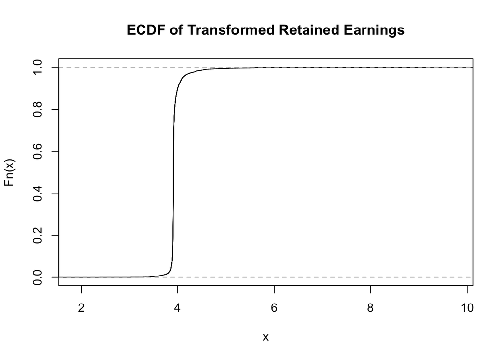

```r
y_train_transformed_logged <- log(y_train + 50)
y_test_transformed_logged <- log(y_test + 50)
y_train_transformed_logged_ecdf <- ecdf(unlist(y_train_transformed_logged))
plot(y_train_transformed_logged_ecdf, main = "ECDF of Transformed Retained Earnings")
```

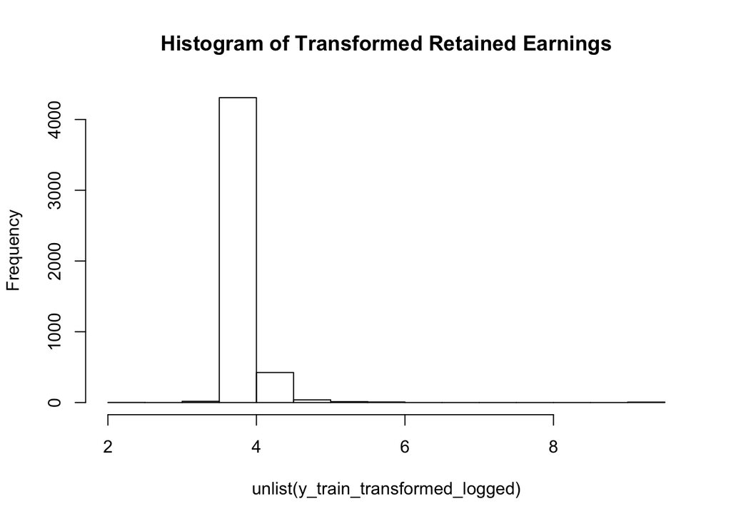

```r
hist(unlist(y_train_transformed_logged), main = "Histogram of Transformed Retained Earnings")
```

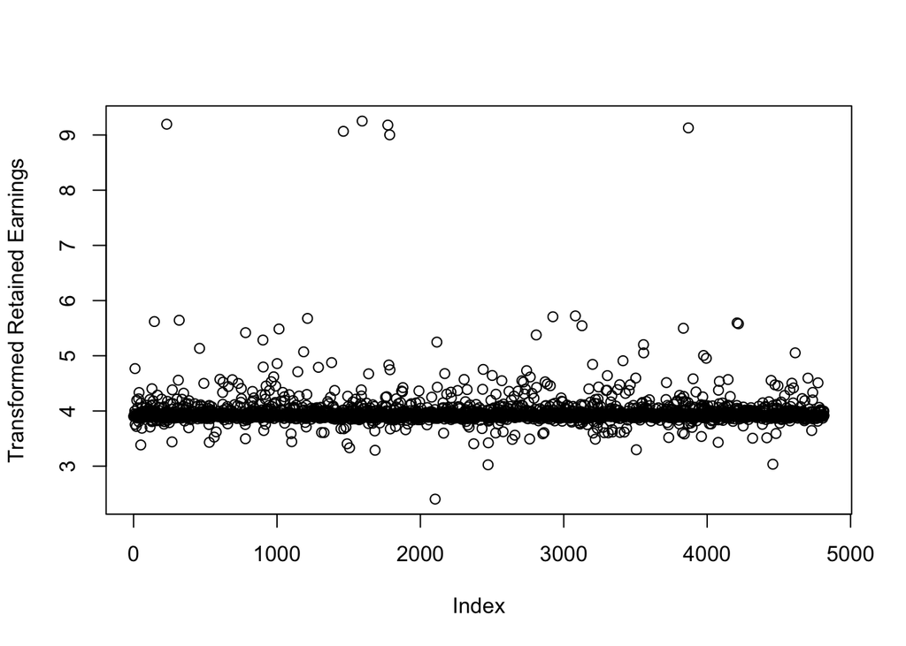

```r
plot(unlist(y_train_transformed_logged), xlab = "Index", ylab = "Transformed Retained Earnings")
```

```r
range(y_train_transformed_logged)
```

```
## [1] 2.402868 9.252166
```

Note that we are still keeping the outliers because while those data points are outliers, we should make our model work for any generalized situations instead of only for perfectly distributed data sets. Instead we decided to keep the outliers but transform the variable as a whole so that even outliers are within a manageable range of values. We will use methods such as Tukey’s bi-weight to down-weigh the outliers during variable selection and model tuning.